Archived executed notebook. Recorded outputs and parameters belong to this earlier study; code inputs and private README are omitted. Return to GeGI saved fields & signals. Use the local guide for supported new calculations.

# GeGI: 3D strip detector simulation

32 orthogonal strips, two guard rings, 11 mm HPGe crystal, -879 V bias, and 92.3 K. The full 3D calculation uses **5,068,800 nodes**. Dimensions and model inputs belong to the earlier study’s private `README.md`, which is not included in this archive.

Recorded notebook kernel: **Julia 1.13 — GeGI**. This archive displays saved outputs; it does not execute cells.

```
  Activating project at `[external local input]`
```

```
Geometry checks passed: 16+16 orthogonal strips, 2 guards, central gaps remain open
Julia 1.13.0 | SSD 0.11.8 | CUDA.jl 6.4.0 | 92.3 K
```

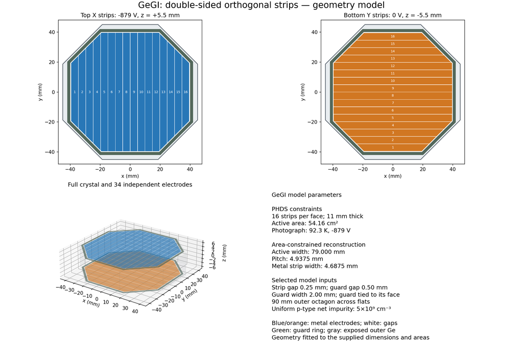

```
GRID (240, 240, 88), nodes=5068800, conservative array budget=1547.0 MiB
```

```
GPU NVIDIA GeForce RTX 4070 Laptop GPU; available 6.9 GiB
```

## Electric potential and field

All 34 electrodes enter the 3D solve. The mesh resolves strip gaps and contact faces; the surrounding vacuum extends to x/y = ±55 mm and z = ±12 mm.

Equipotential contours and in-plane field lines are shown on sections through strip centers. Adaptive RK4 traces terminate at contacts or section boundaries. The second figure enlarges the strip gap.

```
EP continuation 10: 0.0029296875 V
```

```
EP continuation 20: 0.001373291 V
```

```
EP continuation 30: 0.00065612793 V
```

```
EP last-update=0.0004272461 V; requested=0.0004395 V
```

```
Fully depleted in this model: true
```

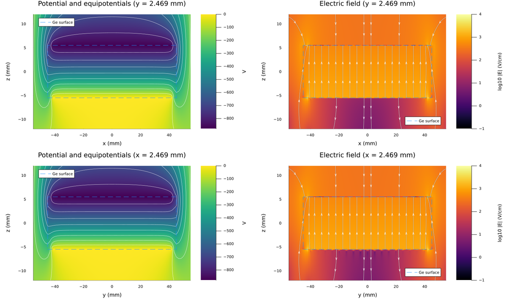

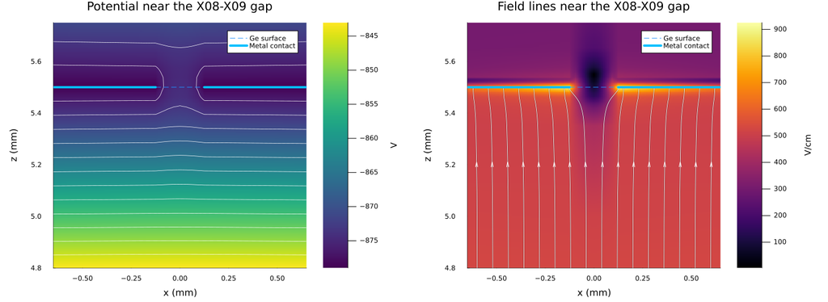

## Weighting potentials

Four weighting potentials cover X08, X09, Y08 and Y09. Each sets its selected electrode to 1 and the other 33 electrodes to 0. The contour plot shows X09.

```
WP 8 X08 initialize
```

```
WP 8 last-update=7.8976154e-7; requested=1.0e-6
```

```
WP 9 X09 initialize
```

```
WP 9 last-update=7.301569e-7; requested=1.0e-6
```

```
WP 25 Y08 initialize
```

```
WP 25 last-update=8.6426735e-7; requested=1.0e-6
```

```
WP 26 Y09 initialize
```

```
WP 26 last-update=7.1525574e-7; requested=1.0e-6
```

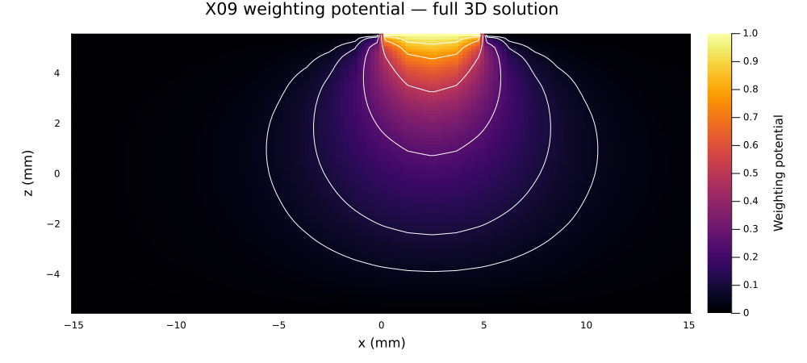

## Charge drift

Six 662 keV point deposits sample the center, different depths, a strip gap, an active edge and a guard. Solid lines show electrons; dashed lines show holes. The drift time step is 0.5 ns.

```
center => (
```

```
electron_id = 26, hole_id = 9, electron_ns = 60.49990020073892, hole_ns = 90.00000744663339, ctd_ns = -29.50010724589447, collected = true)
upper-left / deep => (electron_id = 29, hole_id = 4, electron_ns = 26.500000416262992, hole_ns = 133.49996663691854, ctd_ns = -106.99996266794187, collected = true)
lower-right / shallow => (electron_id = 21, hole_id = 12, electron_ns = 91.50001289981446, hole_ns = 50.99992606005799, ctd_ns = 40.50008683975648, collected = true)
near gap => (electron_id = 23, hole_id = 8, electron_ns = 37.49997290469764, hole_ns = 120.00010940482753, ctd_ns = -82.50013650012988, collected = true)
active edge => (electron_id = 28, hole_id = 16, electron_ns = 72.99994564391454, hole_ns = 74.99995291482264, ctd_ns = -2.0000072709080996, collected = true)
under guard => (electron_id = 34, hole_id = 17, electron_ns = 61.49990383619297, hole_ns = 91.00001108208744, ctd_ns = -29.50010724589447, collected = true)
```

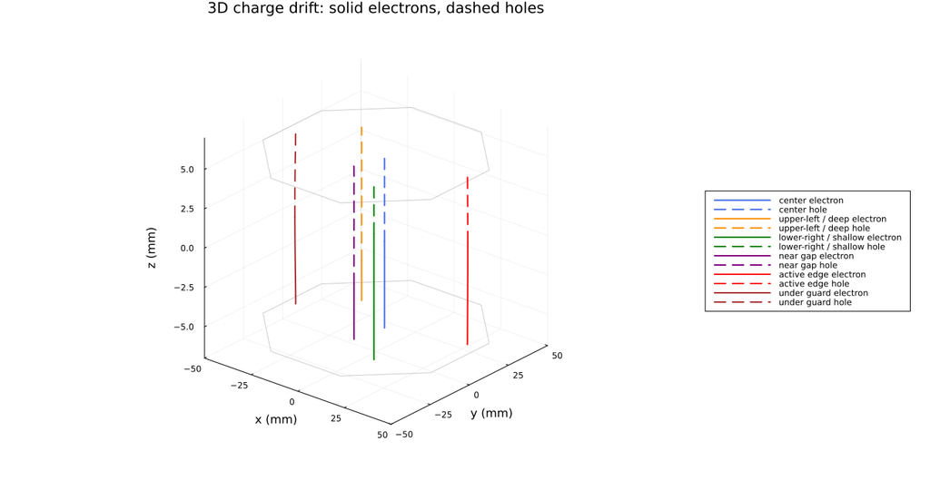

## Induced charge and current

Shockley–Ramo signals for a central 662 keV deposit give approximately ±35.95 fC on the collecting strips, with transient induction on their neighbors. Currents are time derivatives of the induced charge, before electronics processing.

```
Expected full collected charge magnitude: 35.953929888406776 fC; X09=35.95393; Y09=-35.95393
```

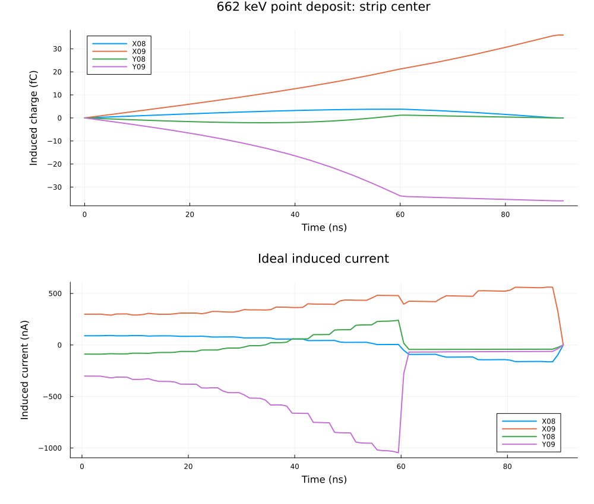

## Collection map

The mid-depth scan maps starting positions to collecting strips and guards. White corners lie outside the crystal. Sampling points are offset from exact gap symmetry lines.

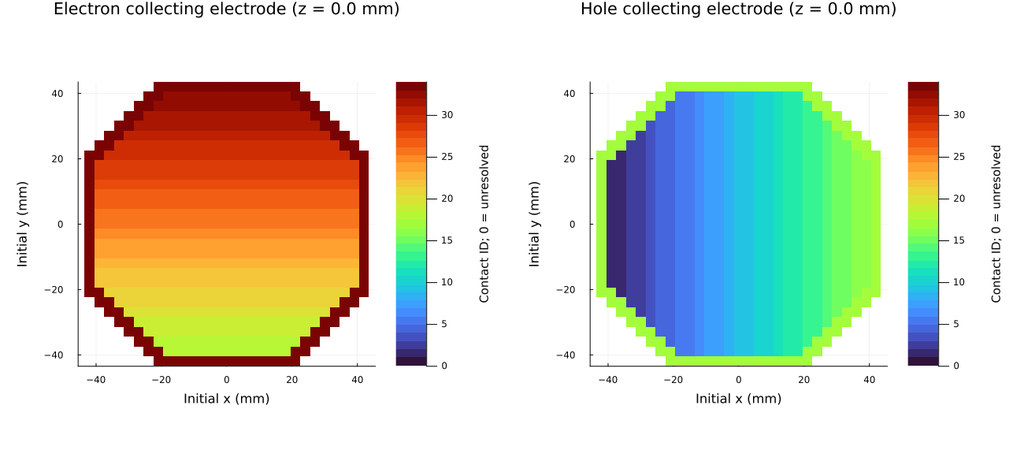

## Charge sharing and diffusion

A Gaussian cloud with σx = 0.10 mm is represented by 48 weighted starting points. Its trajectories separate toward neighboring strips. The sharing curve includes four seeded diffusion realizations using De = 239 and Dh = 279 cm²/s.

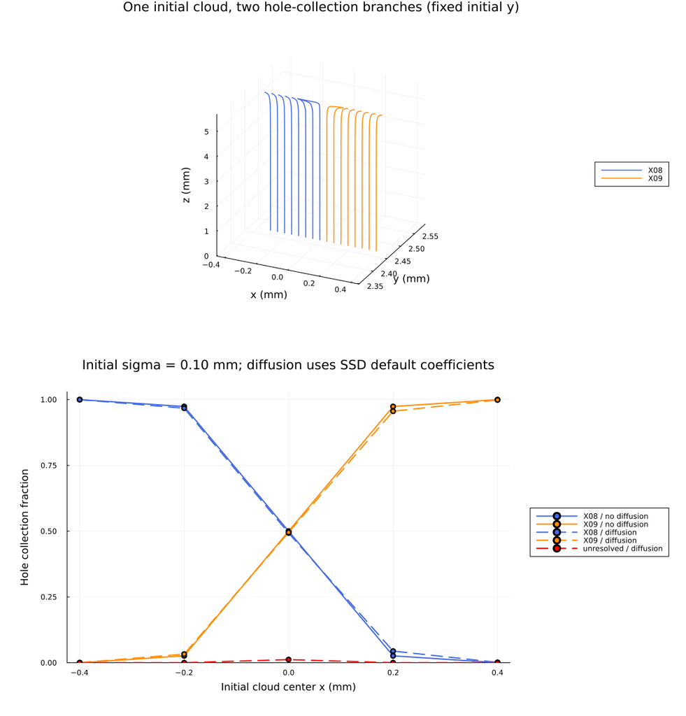

## Depth timing and temperature

Collection-time difference, t_e − t_h, versus depth at 80 and 92.3 K. ADL2016 drift uses Omar1987 temperature scaling with the same electric field and ionized impurity density.

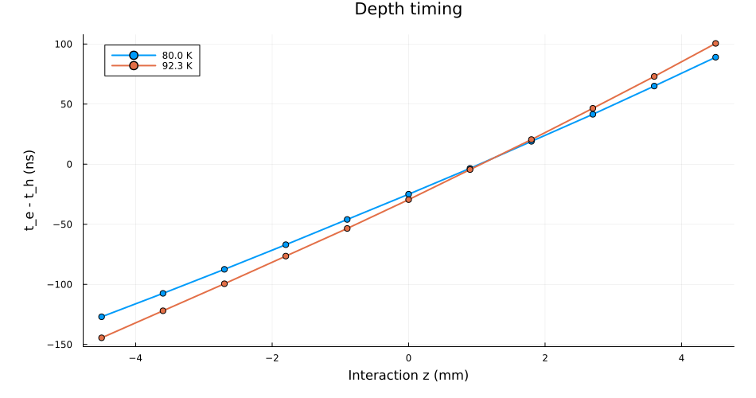

## Saved results

Figures, tables and solved fields are saved in the results folder. Reload `baseline_simulation.jls` with `deserialize` in this project environment.

```
Completed. Results: [external local input]
Solved weighting potentials:
```

```
[8, 9, 25, 26]
```